[Home Page](https://brahmbeyond.github.io/datascinece/)

# CrossValidation

Cross validation is a technique in ML which is used to evalute the performance of a model on unseen data.

Before training our model we need to divide data into parts/segments/folds/subsets etc. Like we have whole data, now we need to train our model and then test it also to see if its working or not. For that dataset is divided into train and test. There are many cross Validation tehniques to do this thing in different manner and each type is suitable for different data and scenerio. Like one may divide data into single split and other might divide it into multiple.

For this first we need to know about the data in the dataset. As we have to test the data means one data is dependent on other data like if we are trying to predict a person's age group by inputing the salary, So, it clearly means that Age is dependent upon Salary. Age Group is dependent data and Salary is Independent Data.  
So we take X as independent data variable and Y as dependent data variable.

### Now we first import the dataset and store the it into X and Y by dividing them

```python
from pandas import read_csv
data = read_csv('iris.csv')      #load iris dataset
data.head(4)
```

|  | sepal.length | sepal.width | petal.length | petal.width | variety |
| --- | --- | --- | --- | --- | --- |
| 0 | 5.1 | 3.5 | 1.4 | 0.2 | Setosa |
| 1 | 4.9 | 3.0 | 1.4 | 0.2 | Setosa |
| 2 | 4.7 | 3.2 | 1.3 | 0.2 | Setosa |
| 3 | 4.6 | 3.1 | 1.5 | 0.2 | Setosa |

```python
# As the above column variety is string so will give error while training as it wants homoegneous data so will
# convert it into number using labelEncoder a Preprocessing technique

from sklearn.preprocessing import LabelEncoder
le = LabelEncoder()
data.variety = le.fit_transform(data.variety)    #Using LabelEncoder to change the value into string
data.head(4)
```

|  | sepal.length | sepal.width | petal.length | petal.width | variety |
| --- | --- | --- | --- | --- | --- |
| 0 | 5.1 | 3.5 | 1.4 | 0.2 | 0 |
| 1 | 4.9 | 3.0 | 1.4 | 0.2 | 0 |
| 2 | 4.7 | 3.2 | 1.3 | 0.2 | 0 |
| 3 | 4.6 | 3.1 | 1.5 | 0.2 | 0 |

```python
# Another method intead of Changing the value to number is that we can call inbuild iris dataset which comes has number
# in classes insetad of string

# from sklearn.datasets import load_iris
# import pandas as pd
# iris = load_iris()
# # print(iris)
# data = pd.DataFrame(iris.data,columns=iris.feature_names)
# data['target']=iris.target                                         #adding the last column 'target' to it as t couldn't be added in first time.
# data.head(4)
```

```python
target_col = 'variety'  #If used Preprocessing
# target_col = 'target'     # if used inbuilt dataset

X = data.drop([target_col],axis='columns')      #gave all columns to it expect for Variety
Y = data[target_col]
```

## Holdout

Holdout Crossvalidation is the simplest of all methods, it invloves splitting the data only single time.

**train_test_split** divides it into 4 parts as X_Train, X_test, Y_tain, Y_test. means dividing the both train and test data into independent and dependent parts.

train_test_split method is imported from sklearn library's model_selection module. `from sklearn.model_selection import train_test_split`

#### parameters used in train_test_split method

- X => independent data
- Y => dependent data
- train_size => Specifies the size of data to be used in training. number between 0 and 1. like 0.8 which means 80 percent of data will be used in training and rest 20% in testing.
- test_size => same as train_size but is used for testing.

The main thing is that you can specify only train or test size but remember when you are specifying the both then addition of both should be equal to 1.

- random_state => This control the randomness of the data and is optional parameter. Let's take a example like if random_state = 1 , so here 1 is set , now when splitting is done, the indices of the data will be will be in random order like 5,3,7,8,1. But whenever you will use this 1 for random_state then the same order will be there for the data which is here 5,3,7,8,1.

It is used in cases when you again need to split the data and if data will be changed everytime on everyrun then it will very difficult to get that order again and without saying it will affect the prediction socre everytime.

- Shuffel => Its value is boolean for True/False , my default it is true. It shuffels the data while splitting

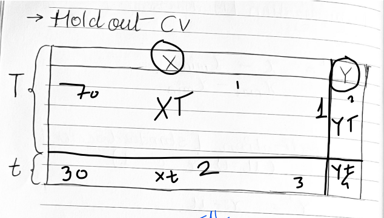

```python
from sklearn.model_selection import train_test_split
X_train,X_test,Y_train,Y_test = train_test_split(X,Y,test_size=0.2,train_size=0.8,random_state=2)
```

```python
print(X_train)
```

```
     sepal.length  sepal.width  petal.length  petal.width
126           6.2          2.8           4.8          1.8
23            5.1          3.3           1.7          0.5
64            5.6          2.9           3.6          1.3
117           7.7          3.8           6.7          2.2
84            5.4          3.0           4.5          1.5
..            ...          ...           ...          ...
75            6.6          3.0           4.4          1.4
43            5.0          3.5           1.6          0.6
22            4.6          3.6           1.0          0.2
72            6.3          2.5           4.9          1.5
15            5.7          4.4           1.5          0.4

[120 rows x 4 columns]
```

```python
from sklearn.linear_model import LinearRegression   #we'll use Linear Regression to train and test model's score.
trainedM = LinearRegression()
trainedM.fit(X_train,Y_train)
```

```
LinearRegression()
```

```python
trainedM.score(X_test,Y_test)
```

```
0.9371534629740856
```

This holdout method as some shortcomings:-

- In this method there is possibility that the main data which you wanted to be in training will be gone instead in test. So it make the accuray low.

When to Choose it:-

- When data is lot and time and resources is low, then training the model on this single splitted data will be efficient
- When you want to quickly evaluate the model's performance on unseen data, but don't need to estimate the performance multiple times.

## K-Fold

To overcome shortcomings of HoldOut Kfold is there. In this the entire dataset is divided into folds.

Like if we divide data into 5 folds. It will divide the data into 5 equal parts. Then while training it will

- first take 1st fold as testing and rest of other 4 for training.
- The in second step it will use second fold for testing and the rest of others for training.
- This goes on until each of the fold is used for testing. So if folds=5 then training will be done in 5 steps.

This helps in training and testing each and every data in the dataset for better prediction results.

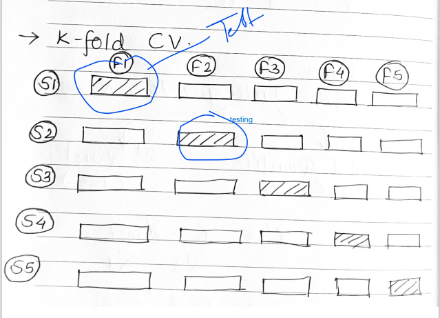

First we need to import the KFold from `sklearn.model_selection` and `cross_val_score` also. KFold is model itself.

- In KFold you need to define the n_splits , means no. of splits which you want.

cross_val_score is used to calculate the score of the cross validation model given to it. Its parameters are :

- model, which model you want to use to train the data on.
- X, the whole dataset's independent value
- Y, the whole dataset's dependent value
- cv, stands for cross validation, in this you have to define the cross validation method you want to use like here it will be KFold.

```python
from sklearn.model_selection import KFold,cross_val_score
```

```python
kf = KFold(n_splits=5)
kf
```

```
KFold(n_splits=5, random_state=None, shuffle=False)
```

```python
score = cross_val_score(trainedM,X,Y,cv=kf)

# here trainedM is the object of LinearRegression method which was defined above in Holdout CV
```

```python
score
```

```
array([0.        , 0.85124923, 0.        , 0.76155439, 0.        ])
```

The cross_val_score will return 5 scores here, because model was spilleted into 5 folds and model was trained 5 times so 5 scores and now we had to get its mean

```python
score.mean()
```

```
0.3225607248900085
```

#### When to choose it:

- when you have time and resources to train a model many times
- when you want your model to do better predictions
- When you want to evaluate the model's performance on unseen data and have a moderate-sized dataset (e.g., hundreds to thousands of samples).

#### Shortcomings:

- In KFold , if model have classes more than one, like here in iris dataset we have 3 classes. So in that the division of classes in each of the fold is not regular(ratio of classes is not same in every fold). Like there might be ratio of classes 2:2:6 in fold one and in other fold there can only class2 there and then ratio will be 0:10:0 , so the ratio is not regular in all folds in KFold so it dosn't provide accurate results.

**To overcome KFold's shortcoming StratifiedKFold was introduces in which all folds will have same class ratios.**

## Stratified KFold

This is same as KFold model but with improvement, as each of the fold it is splitted into has same classes ratios. Means if a dataset has 2 classes and ratio is 60:40 then each of the fold will have same 60:40 ratio.

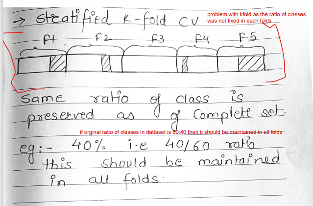

```python
from sklearn.model_selection import StratifiedKFold,cross_val_score
```

```python
skf = StratifiedKFold(n_splits=5)
skf
```

```
StratifiedKFold(n_splits=5, random_state=None, shuffle=False)
```

```python
score = cross_val_score(trainedM,X,Y,cv=skf)
score
```

```
array([0.93419651, 0.93960249, 0.89937482, 0.90264936, 0.95607441])
```

```python
score.mean()
```

```
0.9263795181390904
```

You can how much difference in th score is from KFold.

When to use:

- When you have a classification problem with imbalanced classes (i.e., one class has a significantly larger number of samples than others) and want to ensure that each fold has a similar class distribution.

Shortcoming:

- The choice of k can still affect the results, and StratifiedKFold can be computationally expensive for large datasets.

## Leave P Out

In this the value of P has to be specified then that much number of data samples is taken for test and rest for training in each step.

Like if total are 5 samples (1,2,3,4,5) in a dataset and P = 2, then what will happen is, in each step, 2 data samples will be used in testing and other 3 in training. Now we are talking about each step then how many steps will be there !!? This will work like this => first sample here 1 will form a combination with every other sample in each step to be used for test and remaining will be used in training. like

- step1. test(1,2) train(3,4,5)
- step2. test(1,3) train(2,4,5)
- step3. test(1,4) train(2,3,5)
- step4. test(1,5) train(2,3,4)
- step6. test(2,3) train(1,4,5) now this will go on.... and no same will be repeated and no same sample will be in together in test like no (5,5).

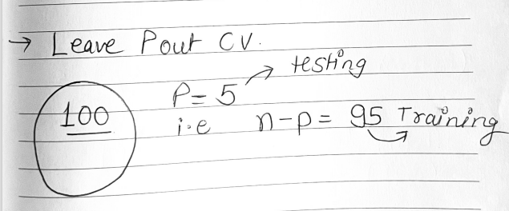

```python
from sklearn.model_selection import LeavePOut
lp = LeavePOut(p=2)
lp
```

```
LeavePOut(p=2)
```

```python
lp.get_n_splits(X)            #get number of splits will be made
```

```
11175
```

```python
score=cross_val_score(trainedM,X,Y,cv=lp)
score
```

```
array([0., 0., 0., ..., 0., 0., 0.])
```

```python
score.mean()
```

```
0.5650161063550495
```

When to use it:

- When you want your model to be highly accurate
- When you have high resources as this is computationaly expensive as you can the number of splits it perfomed.

## Leave One Out

Works same as LEave P Out but in this only 1 sample is used for test everytime rather than 2.

In this one sample is used for testing and other remaning are used for training on each step. Like if you have 5 samples in dataset then in each step one sample will be used for testing and other remaining will be used for training. The steps will be completed when all samples are used for testing. So ' steps = no. of samples in dataset '

We don't have define the number of splits here as per its name its always one.

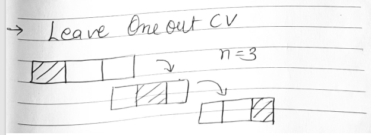

```python
from sklearn.model_selection import LeaveOneOut,cross_val_score
```

```python
lo = LeaveOneOut()
lo
```

```
LeaveOneOut()
```

```python
lo.get_n_splits(X)
```

```
150
```

```python
from sklearn.naive_bayes import GaussianNB
classifier1 = GaussianNB()
# choosing here naive bayes as Linear Regression was giving error 'UndefinedMetricWarning ' as there was only one sample given.
```

```python
score=cross_val_score(classifier1,X,Y,cv=lo)
score
```

```
array([1., 1., 1., 1., 1., 1., 1., 1., 1., 1., 1., 1., 1., 1., 1., 1., 1.,
       1., 1., 1., 1., 1., 1., 1., 1., 1., 1., 1., 1., 1., 1., 1., 1., 1.,
       1., 1., 1., 1., 1., 1., 1., 1., 1., 1., 1., 1., 1., 1., 1., 1., 1.,
       1., 0., 1., 1., 1., 1., 1., 1., 1., 1., 1., 1., 1., 1., 1., 1., 1.,
       1., 1., 0., 1., 1., 1., 1., 1., 1., 0., 1., 1., 1., 1., 1., 1., 1.,
       1., 1., 1., 1., 1., 1., 1., 1., 1., 1., 1., 1., 1., 1., 1., 1., 1.,
       1., 1., 1., 1., 0., 1., 1., 1., 1., 1., 1., 1., 1., 1., 1., 1., 1.,
       0., 1., 1., 1., 1., 1., 1., 1., 1., 1., 1., 1., 1., 1., 0., 0., 1.,
       1., 1., 1., 1., 1., 1., 1., 1., 1., 1., 1., 1., 1., 1.])
```

```python
score.mean()
```

```
0.9533333333333334
```

Shortcoming:

- can be computationally expensive and may not provide a reliable estimate of the model's performance, especially for large datasets.

## Extras

One more thing, whatif we don't provide the cv value in the **cross_val_score** !! Lets see that

```python
from sklearn.model_selection import cross_val_score

score=cross_val_score(classifier1,X,Y)              #uses Sratified KFold as classifier1(model) here is GaussianNB
# score=cross_val_score(trainedM,X,Y)               #uses Kfold as as trainedM here is(model)  LinearRegression

score
```

```
array([0.93333333, 0.96666667, 0.93333333, 0.93333333, 1.        ])
```

```python
score.mean()
```

```
0.9533333333333334
```

- Here if you don't specify the value of cv it will use by default 5 splits and
- the crossvalidation method it will use will depend upon the model that is given to it.

Like if a classification model is given then it will use Stratified KFold and if other estimater model is given to it then it will use KFold only.

#### images are from DataScience Workshop taught by Shridhar Mankar.